# Segmentação de Clientes - RFM Analysis

Segmentação de clientes para elaboração de campanhas customizadas de Marketing através da análise RFM.

Esse é um projeto de análise de dados.

Disponível também em meu [github](https://github.com/ds-rafaelfelippe/DataAnalysisRFM).

O conjunto de dados utilizado está disponível [neste link](https://www.kaggle.com/datasets/rodsaldanha/arketing-campaign).

## 1. Entendimento do Negócio

A BestShop é uma empresa em expansão que comercializa produtos, principalmente alimentícios, através de lojas físicas e de maneira virtual.

Visando otimizar ainda mais suas vendas, a empresa contratou um consultor em ciência de dados para realizar a segmentação de seus clientes. O principal objetivo desse projeto é identificar padrões de consumo para realizar campanhas de Marketing customizadas e consequentemente mais assertivas, visto que atualmente, as taxas de conversão das campanhas são baixas.

Durante a reunião de negócios, vários métodos de como realizar a segmentação dos clientes foram debatidos. Ao final, foi decidido que para o primeiro ciclo do projeto, o cientista de dados deverá utilizar a análise RFM e assim, sugerir recomendações de ações para o time de Marketing.

### 1.1 Dicionário de Dados

Em relação ao conjunto de dados, as seguintes informações foram disponibilizadas:

| Categoria | Variáveis | Descrição |
| --- | --- | --- |
| Clientes | ID | Identificação do cliente |
|  | Year_Birth | Ano de nascimento |
|  | Education | Nível educacional |
|  | Marital_Status | Estado civil |
|  | Income | Renda familiar anual |
|  | Kidhome | Número de crianças que moram na casa |
|  | Teenhome | Número de adolescentes que moram na casa |
|  | Dt_Customer | Data que o consumidor se inscreveu na loja |
|  | Recency | Número de dias desde a última compra do cliente |
|  | Complain | 1 se o cliente reclamar nos últimos 2 anos, 0 caso contrário |
| Produtos | MntWines | Quantidade gasta em vinho nos últimos 2 anos |
|  | MntFruits | Quantidade gasta com frutas nos últimos 2 anos |
|  | MntMeatProducts | Quantidade gasta com carne nos últimos 2 anos |
|  | MntFishProduct | Quantidade gasta em peixe nos últimos 2 anos |
|  | MntSweetProducts | Quantia gasta em doces nos últimos 2 anos |
|  | MntGoldProds | Quantia gasta em ouro nos últimos 2 anos |
| Promoção | NumDealsPurchases | Número de compras feitas com desconto |
|  | AcceptedCmp1 | 1 se o cliente aceitou a oferta na 1° campanha, 0 caso contrário |
|  | AcceptedCmp2 | 1 se o cliente aceitou a oferta na 2° campanha, 0 caso contrário |
|  | AcceptedCmp3 | 1 se o cliente aceitou a oferta na 3° campanha, 0 caso contrário |
|  | AcceptedCmp4 | 1 se o cliente aceitou a oferta na 4° campanha, 0 caso contrário |
|  | AcceptedCmp5 | 1 se o cliente aceitou a oferta na 5° campanha, 0 caso contrário |
|  | Response | 1 se o cliente aceitou a oferta na última campanha, 0 caso contrário |
| Local de Compra | NumWebPurchases | Número de compras feitas por meio do site da empresa |
|  | NumCatalogPurchases | Número de compras feitas usando um catálogo |
|  | NumStorePurchases | Número de compras feitas diretamente nas lojas |
|  | NumWebVisitsMonth | Número de visitas ao site da empresa no último mês |

### 1.2 Estratégia da Solução

Como estratégia para a solução do projeto, definimos as seguintes etapas:

- **1. Entendimento do Negócio:** nesta etapa inicial, o principal objetivo é compreender o problema de negócio e as necessidades do cliente.
- **2. Entendimento dos Dados:** iremos tratar as principais inconsistências encontradas nos dados, e realizar uma análise exploratória a fim de gerar insights sobre o negócio.
- **3. Engenharia de Atributos:** com os dados existentes, criaremos variáveis a fim de extrair novas informações dos dados.
- **4. Perguntas e Hipóteses de Negócio:** ainda como forma de explorar os dados, criaremos perguntas e hipóteses relacionadas ao problema de negócio.
- **5. Análise RFM:** através da análise RFM, iremos segmentar os clientes da empresa.
- **6. Recomendações para Área de Marketing:** nessa etapa, iremos sugerir algumas recomendações para a área de Marketing.
- **7. Conclusões Finais:** por fim, concluiremos o projeto com as considerações finais.

## 2. Entendimento dos Dados

Vamos iniciar o projeto carregando as bibliotecas necessárias e os conjuntos de dados.

### 2.1 Bibliotecas Necessárias

```python
# Filtragem das mensagens de avisos.
import warnings
warnings.filterwarnings('ignore')

# Manipulação de dados.
from datetime import datetime
import numpy as np
import pandas as pd

# Criação de gráficos.
import matplotlib.pyplot as plt
import seaborn as sns
```

```python
# Versão da linguagem Python.
from platform import python_version
print('Versão da linguagem Python:', python_version())
```

```
Versão da linguagem Python: 3.9.12
```

```python
# Versão dos pacotes.
%reload_ext watermark
%watermark --iversions
```

```
numpy     : 1.21.5
seaborn   : 0.11.2
matplotlib: 3.5.1
pandas    : 1.4.2
```

```python
# Configurações do notebook.

# Plotagens.
from matplotlib import rcParams
rcParams['figure.figsize'] = 15, 10
rcParams['lines.linewidth'] = 1

# Estilo dos gráficos.
plt.style.use('ggplot')

# Configuração Dataframe.
pd.set_option('display.max_columns', None)
```

### 2.2 Tratamento Inicial dos Dados

Nessa etapa, nosso objetivo é realizar uma análise geral nos dados a fim de tratar possíveis inconsistências.

```python
# Carregando o conjunto de dados.
df = pd.read_csv('data/marketing_campaign.csv', sep = ';')
```

```python
# Cópia do dataset.
df1 = df
```

```python
# Visualizando o conjunto de dados.
df1.head()
```

|  | ID | Year_Birth | Education | Marital_Status | Income | Kidhome | Teenhome | Dt_Customer | Recency | MntWines | MntFruits | MntMeatProducts | MntFishProducts | MntSweetProducts | MntGoldProds | NumDealsPurchases | NumWebPurchases | NumCatalogPurchases | NumStorePurchases | NumWebVisitsMonth | AcceptedCmp3 | AcceptedCmp4 | AcceptedCmp5 | AcceptedCmp1 | AcceptedCmp2 | Complain | Z_CostContact | Z_Revenue | Response |
| --- | --- | --- | --- | --- | --- | --- | --- | --- | --- | --- | --- | --- | --- | --- | --- | --- | --- | --- | --- | --- | --- | --- | --- | --- | --- | --- | --- | --- | --- |
| 0 | 5524 | 1957 | Graduation | Single | 58138.0 | 0 | 0 | 2012-09-04 | 58 | 635 | 88 | 546 | 172 | 88 | 88 | 3 | 8 | 10 | 4 | 7 | 0 | 0 | 0 | 0 | 0 | 0 | 3 | 11 | 1 |
| 1 | 2174 | 1954 | Graduation | Single | 46344.0 | 1 | 1 | 2014-03-08 | 38 | 11 | 1 | 6 | 2 | 1 | 6 | 2 | 1 | 1 | 2 | 5 | 0 | 0 | 0 | 0 | 0 | 0 | 3 | 11 | 0 |
| 2 | 4141 | 1965 | Graduation | Together | 71613.0 | 0 | 0 | 2013-08-21 | 26 | 426 | 49 | 127 | 111 | 21 | 42 | 1 | 8 | 2 | 10 | 4 | 0 | 0 | 0 | 0 | 0 | 0 | 3 | 11 | 0 |
| 3 | 6182 | 1984 | Graduation | Together | 26646.0 | 1 | 0 | 2014-02-10 | 26 | 11 | 4 | 20 | 10 | 3 | 5 | 2 | 2 | 0 | 4 | 6 | 0 | 0 | 0 | 0 | 0 | 0 | 3 | 11 | 0 |
| 4 | 5324 | 1981 | PhD | Married | 58293.0 | 1 | 0 | 2014-01-19 | 94 | 173 | 43 | 118 | 46 | 27 | 15 | 5 | 5 | 3 | 6 | 5 | 0 | 0 | 0 | 0 | 0 | 0 | 3 | 11 | 0 |

```python
# Dimensão do dataframe.
print('Número de registros: {}'.format(df1.shape[0]))
print('Número de variáveis: {}'.format(df1.shape[1]))
```

```
Número de registros: 2240
Número de variáveis: 29
```

```python
# Informações do dataframe.
df1.info()
```

```
<class 'pandas.core.frame.DataFrame'>
RangeIndex: 2240 entries, 0 to 2239
Data columns (total 29 columns):
 #   Column               Non-Null Count  Dtype
---  ------               --------------  -----
 0   ID                   2240 non-null   int64
 1   Year_Birth           2240 non-null   int64
 2   Education            2240 non-null   object
 3   Marital_Status       2240 non-null   object
 4   Income               2216 non-null   float64
 5   Kidhome              2240 non-null   int64
 6   Teenhome             2240 non-null   int64
 7   Dt_Customer          2240 non-null   object
 8   Recency              2240 non-null   int64
 9   MntWines             2240 non-null   int64
```

[output cut: 21 more lines]

```python
# Registros ausentes.

# Obtendo os dados.
valores_ausentes = df1.isnull().sum()
contatem_total = df1.isnull().count()
porcentagem = round(valores_ausentes / contatem_total * 100, 2)

# Criando o dataframe.
df_ausentes = pd.DataFrame({'Total de Valores Ausentes': valores_ausentes, 'Porcentagem': porcentagem})
df_ausentes
```

|  | Total de Valores Ausentes | Porcentagem |
| --- | --- | --- |
| ID | 0 | 0.00 |
| Year_Birth | 0 | 0.00 |
| Education | 0 | 0.00 |
| Marital_Status | 0 | 0.00 |
| Income | 24 | 1.07 |
| Kidhome | 0 | 0.00 |
| Teenhome | 0 | 0.00 |
| Dt_Customer | 0 | 0.00 |
| Recency | 0 | 0.00 |
| MntWines | 0 | 0.00 |
| MntFruits | 0 | 0.00 |
| MntMeatProducts | 0 | 0.00 |
| MntFishProducts | 0 | 0.00 |
| MntSweetProducts | 0 | 0.00 |
| MntGoldProds | 0 | 0.00 |
| NumDealsPurchases | 0 | 0.00 |
| NumWebPurchases | 0 | 0.00 |
| NumCatalogPurchases | 0 | 0.00 |
| NumStorePurchases | 0 | 0.00 |
| NumWebVisitsMonth | 0 | 0.00 |
| AcceptedCmp3 | 0 | 0.00 |
| AcceptedCmp4 | 0 | 0.00 |
| AcceptedCmp5 | 0 | 0.00 |
| AcceptedCmp1 | 0 | 0.00 |
| AcceptedCmp2 | 0 | 0.00 |
| Complain | 0 | 0.00 |
| Z_CostContact | 0 | 0.00 |
| Z_Revenue | 0 | 0.00 |
| Response | 0 | 0.00 |

A variável **`Income`** possui 24 valores ausentes, o que representa pouco mais de 1% dos dados.

Como são poucos registros, podemos excluí-los da análise.

```python
# Dimensão original.
shape_original = df1.shape
print('Antes: ', shape_original)

# Excluindo os registros inválidos.
df1.dropna(subset = ['Income'], inplace = True)

# Dimensão após o tratamento.
shape_tratado = df1.shape
print('Depois: ', shape_tratado)
```

```
Antes:  (2240, 29)
Depois:  (2216, 29)
```

```python
# Registros únicos de cada variável.
for col in df1:
    print(f'''Registros únicos da Variável {col}:''')
    print(df1[col].nunique())
    print()
```

```
Registros únicos da Variável ID:
2216

Registros únicos da Variável Year_Birth:
59

Registros únicos da Variável Education:
5

Registros únicos da Variável Marital_Status:
8

Registros únicos da Variável Income:
1974

Registros únicos da Variável Kidhome:
3

Registros únicos da Variável Teenhome:
3

Registros únicos da Variável Dt_Customer:
662

Registros únicos da Variável Recency:
100

Registros únicos da Variável MntWines:
776

Registros únicos da Variável MntFruits:
158

Registros únicos da Variável MntMeatProducts:
554

Registros únicos da Variável MntFishProducts:
182

Registros únicos da Variável MntSweetProducts:
```

[output cut: 31 more lines]

```

Registros únicos da Variável AcceptedCmp2:
2

Registros únicos da Variável Complain:
2

Registros únicos da Variável Z_CostContact:
1

Registros únicos da Variável Z_Revenue:
1

Registros únicos da Variável Response:
2
```

As variáveis **`Z_CostContact`** e **`Z_Revenue`** possuem apenas um valor único, sendo assim, iremos excluí-las.

```python
# Excluindo as variáveis.
df1 = df1.drop(['Z_CostContact', 'Z_Revenue'], axis = 1)
```

```python
# Cópia do dataframe.
df2 = df1.copy()
```

Realizamos uma análise geral nos dados tratando as principais inconsistências observadas, agora, partiremos para uma análise mais detalhada.

### 2.3 Análise Exploratória

Baseado no dicionário de dados, vamos separar as variáveis.

```python
# Identificação dos clientes.
id_clientes = ['ID']
```

```python
# Variável periódica.
data = ['Dt_Customer']

# Convertendo o tipo da variável.
df2['Dt_Customer'] = pd.to_datetime(df2['Dt_Customer'])
```

```python
# Variáveis numéricas.
nums = ['Year_Birth',
        'Income',
        'Kidhome',
        'Teenhome',
        'Recency',
        'MntWines',
        'MntFruits',
        'MntMeatProducts',
        'MntFishProducts',
        'MntSweetProducts',
        'MntGoldProds',
        'NumDealsPurchases',
        'NumWebPurchases',
        'NumCatalogPurchases',
        'NumStorePurchases',
        'NumWebVisitsMonth']
```

```python
# Variáveis categóricas.
cats = ['Education',
        'Marital_Status',
        'AcceptedCmp1',
        'AcceptedCmp2',
        'AcceptedCmp3',
        'AcceptedCmp4',
        'AcceptedCmp5',
        'Complain',
        'Response']
```

```python
# Total de variáveis nas listas.
len(id_clientes + data + nums + cats)
```

```
27
```

#### 2.3.1 Variável Periódica

```python
# Datas do conjunto de dados.
print('Data início: {}'.format(df2['Dt_Customer'].min()))
print('Data final: {}'.format(df2['Dt_Customer'].max()))
```

```
Data início: 2012-07-30 00:00:00
Data final: 2014-06-29 00:00:00
```

A base de dados possui registros de clientes que se inscreveram entre as datas de 30/07/2012 a 29/06/2014.

#### 2.3.2 Variáveis Numéricas

```python
# Estatísticas das variáveis.
df2[nums].describe().T
```

|  | count | mean | std | min | 25% | 50% | 75% | max |
| --- | --- | --- | --- | --- | --- | --- | --- | --- |
| Year_Birth | 2216.0 | 1968.820397 | 11.985554 | 1893.0 | 1959.0 | 1970.0 | 1977.00 | 1996.0 |
| Income | 2216.0 | 52247.251354 | 25173.076661 | 1730.0 | 35303.0 | 51381.5 | 68522.00 | 666666.0 |
| Kidhome | 2216.0 | 0.441787 | 0.536896 | 0.0 | 0.0 | 0.0 | 1.00 | 2.0 |
| Teenhome | 2216.0 | 0.505415 | 0.544181 | 0.0 | 0.0 | 0.0 | 1.00 | 2.0 |
| Recency | 2216.0 | 49.012635 | 28.948352 | 0.0 | 24.0 | 49.0 | 74.00 | 99.0 |
| MntWines | 2216.0 | 305.091606 | 337.327920 | 0.0 | 24.0 | 174.5 | 505.00 | 1493.0 |
| MntFruits | 2216.0 | 26.356047 | 39.793917 | 0.0 | 2.0 | 8.0 | 33.00 | 199.0 |
| MntMeatProducts | 2216.0 | 166.995939 | 224.283273 | 0.0 | 16.0 | 68.0 | 232.25 | 1725.0 |
| MntFishProducts | 2216.0 | 37.637635 | 54.752082 | 0.0 | 3.0 | 12.0 | 50.00 | 259.0 |
| MntSweetProducts | 2216.0 | 27.028881 | 41.072046 | 0.0 | 1.0 | 8.0 | 33.00 | 262.0 |
| MntGoldProds | 2216.0 | 43.965253 | 51.815414 | 0.0 | 9.0 | 24.5 | 56.00 | 321.0 |
| NumDealsPurchases | 2216.0 | 2.323556 | 1.923716 | 0.0 | 1.0 | 2.0 | 3.00 | 15.0 |
| NumWebPurchases | 2216.0 | 4.085289 | 2.740951 | 0.0 | 2.0 | 4.0 | 6.00 | 27.0 |
| NumCatalogPurchases | 2216.0 | 2.671029 | 2.926734 | 0.0 | 0.0 | 2.0 | 4.00 | 28.0 |
| NumStorePurchases | 2216.0 | 5.800993 | 3.250785 | 0.0 | 3.0 | 5.0 | 8.00 | 13.0 |
| NumWebVisitsMonth | 2216.0 | 5.319043 | 2.425359 | 0.0 | 3.0 | 6.0 | 7.00 | 20.0 |

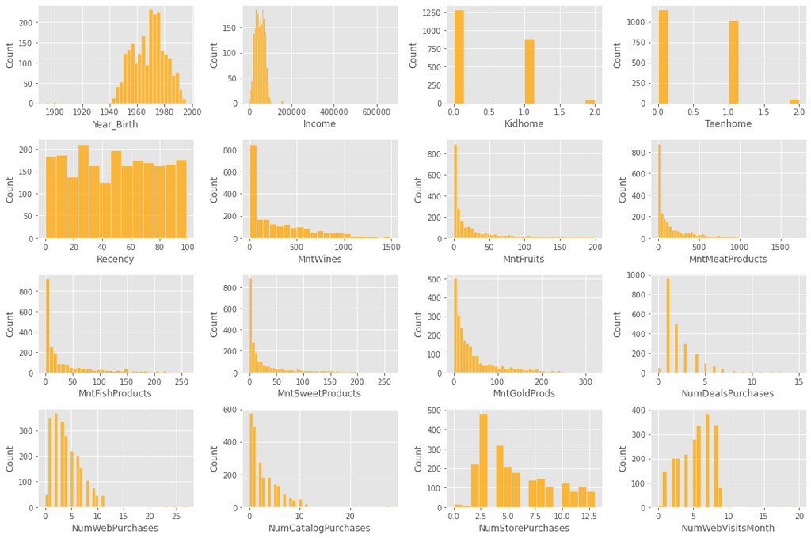

```python
# Histogramas das variáveis.

# Especificando as variáveis.
features = nums

# Plotagem.
for i in range(0, len(nums)):
    plt.subplot(4, 4, i + 1)
    sns.histplot(x = df2[features[i]], color = 'orange')
    plt.xlabel(features[i])
    plt.tight_layout()
```

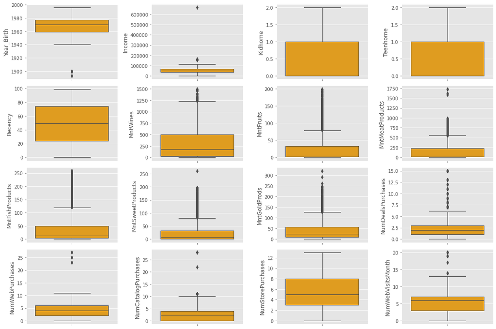

```python
# Boxplots das variáveis.

# Especificando as variáveis.
features = nums

# Plotagem.
for col in range(0, len(features)):
    plt.subplot(4, 4, col + 1)
    sns.boxplot(y = df2[features[col]], color = 'orange')
    plt.tight_layout()
```

#### 2.3.3 Tratando Valores Outliers

Iremos tratar as seguintes variáveis:

- **`Year_Birth`** possui registros muito antigos.
  - A idade máxima considerada será de 100 anos.
- **`Income`** possui valores *outliers*, ou seja, valores muito distantes da média.
  - O limite de corte será a média da variável + 3 x o valor do desvio padrão.

```python
# Contagem de registros antes do tratamento.
print(f'Número de linhas antes de filtrar valores extremos (outliers): {len(df2)}')
```

```
Número de linhas antes de filtrar valores extremos (outliers): 2216
```

```python
# Limite de corte para variável "Income".
limite = df2['Income'].mean() + 3 * df2['Income'].std()
print('Desconsiderar valores acima de:', limite)
```

```
Desconsiderar valores acima de: 127766.48133649485
```

```python
# Tratando os valores outliers.
df2 = df2[(df2['Year_Birth'] >= 1922) & (df2['Income'] <= limite)]
```

```python
# Contagem de registros após o tratamento.
print(f'Número de linhas após filtrar valores extremos (outliers): {len(df2)}')
```

```
Número de linhas após filtrar valores extremos (outliers): 2205
```

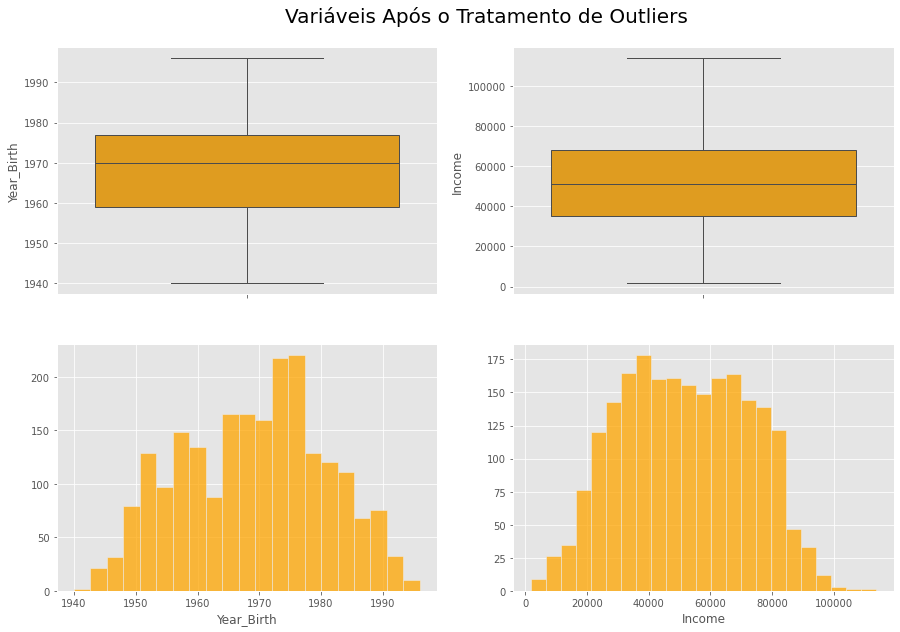

```python
# Variáveis após o tratamento.

# Plotagem.
plt.subplot(2, 2, 1)
p1 = sns.boxplot(y = df2['Year_Birth'], color = 'orange')

plt.subplot(2, 2, 2)
p2 = sns.boxplot(y = df2['Income'], color = 'orange')

plt.subplot(2, 2, 3)
p3 = sns.histplot(df2['Year_Birth'], color = 'orange')
p3.set_ylabel('')

plt.subplot(2, 2, 4)
p4 = sns.histplot(df2['Income'], color = 'orange')
p4.set_ylabel('')

# Título.
p1.text(x = 0.1,
        y = 2005,
        s = 'Variáveis Após o Tratamento de Outliers',
        fontsize = 20);
```

#### 2.3.4 Variáveis Categóricas

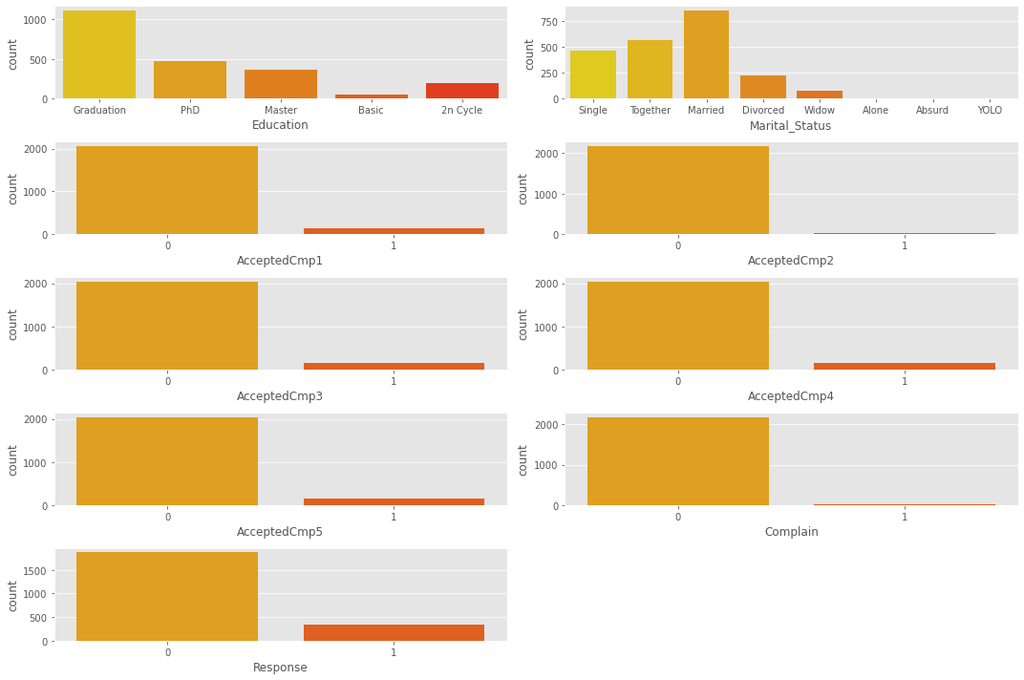

```python
# Análise univariada.

# Especificando as variáveis.
features = cats

# Plotagem.
for i in range(0, len(features)):
    plt.subplot(5, 2, i + 1)
    sns.countplot(x = df2[cats[i]], palette = 'autumn_r')
    plt.tight_layout()
```

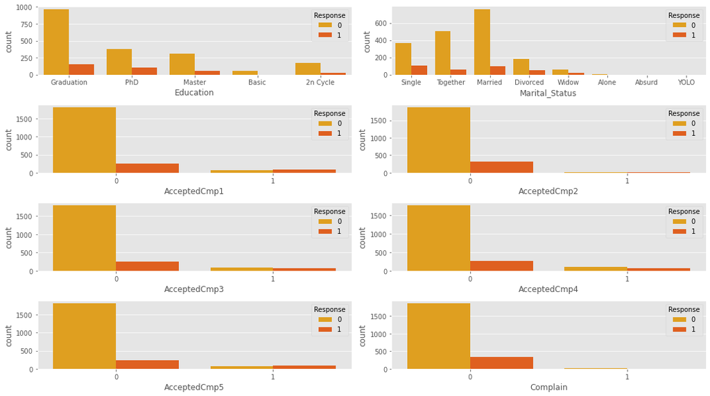

```python
# Análise bivariada ("Response").

# Especificando as variáveis.
features = cats[:-1]

# Plotagem.
for i in range(0, len(features)):
    plt.subplot(5, 2, i + 1)
    sns.countplot(data = df2,
                  x = features[i],
                  hue = 'Response',
                  palette = 'autumn_r')
    plt.tight_layout()
```

```python
# Cópia do dataframe.
df3 = df2.copy()
```

## 3. Engenharia de Atributos

As seguintes variáveis serão criadas de acordo com as regras abaixo:

- **`Age`** informa a idade do cliente.
  - 2015 (ano seguinte ao último registro do dataset) - ano de nascimento.
- **`Group_Age`** informa a que grupo o cliente pertence conforme sua idade.
  - 1 = clientes de 18 a 25 anos;
  - 2 = clientes de 25 a 40 anos;
  - 3 = clientes de 40 a 60 anos;
  - 4 = clientes de 60 a 100 anos.
- **`Graduate`** informa se o cliente possui ensino básico ou superior.
- **`Relationship`** informa se o cliente é solteiro ou casado.
- **`Kids`** informa a quantidade de filhos do cliente (*Kidhome* + *Teenhome*).
- **`CurrentDay`** será utilizada para o calcular o tempo de vida do cliente.
  - Receberá a data (mês e ano) seguinte ao último registro do dataset.
- **`CustomerMonth`** informa o tempo de vida do cliente (em meses).
- **`TotalProd`** total de produtos vendidos.
  - Receberá o valor da soma das 6 categorias de produtos.
- **`TotalPurchases`** total de vendas realizadas.
  - Receberá o valor da soma das 4 categorias dos locais de compras.
- **`TotalPromo`** informa a quantidade de campanhas de marketing que o cliente aceitou.
  - Receberá o valor da soma das variáveis referentes as campanhas de marketing.

```python
# Variável "Age".
df3.insert(2, 'Age', 2015 - df3['Year_Birth'])

# Informações da variável.
print('A menor idade é: {} anos'.format(df3['Age'].min()))
print('A maior idade é: {} anos'.format(df3['Age'].max()))
```

```
A menor idade é: 19 anos
A maior idade é: 75 anos
```

```python
# Variável "GroupAge".

# Definindo os valores e labels.
bins_age = [18, 25, 40, 60, 100]
labels_age = [1, 2, 3, 4]

# Criando a variável.
df3.insert(3, 'GroupAge', pd.cut(df3['Age'], bins_age, labels = labels_age).astype('int64'))
```

```python
# Variável "Graduate".
df3.insert(5, 'Graduate', df3['Education'].apply(lambda x: 'Básico' if x == 'Basic' else 'Superior'))
```

```python
# Variável "Relationship".
df3.insert(7, 'Relationship', df3['Marital_Status'].copy())

# Substituindo os valores.
df3['Relationship'] = df3['Relationship'].replace(['Single', 'Divorced', 'Widow', 'Alone', 'Absurd', 'YOLO'], 'Solteiro')
df3['Relationship'] = df3['Relationship'].replace(['Married', 'Together'], 'Casado')
```

```python
# Variável "Kids".
df3.insert(11, 'Kids', df3['Kidhome'] + df3['Teenhome'])
```

```python
# Variável "CurrentDay".
df3.insert(13, 'CurrentDay', datetime.strptime('2014-07', '%Y-%m'))
```

```python
# Variável "CustomerMonth".
df3.insert(14, 'CustomerMonth', ((df3['CurrentDay'] - df3['Dt_Customer']) / 30).apply(lambda x: x.days).astype('int64'))
```

```python
# Variável "TotalProd".
df3.insert(22, 'TotalProd',
           df3['MntWines'] +
           df3['MntFruits'] +
           df3['MntMeatProducts'] +
           df3['MntFishProducts'] +
           df3['MntSweetProducts'] +
           df3['MntGoldProds'])
```

```python
# Variável "TotalPurchases".
df3.insert(27, 'TotalPurchases',
           df3['NumDealsPurchases'] +
           df3['NumWebPurchases'] +
           df3['NumCatalogPurchases'] +
           df3['NumStorePurchases'])
```

```python
# Variável "TotalPromo".
df3.insert(36, 'TotalPromo',
           df3['AcceptedCmp1'] +
           df3['AcceptedCmp2'] +
           df3['AcceptedCmp3'] +
           df3['AcceptedCmp4'] +
           df3['AcceptedCmp5'] +
           df3['Response'])
```

```python
# Cópia do dataframe.
df4 = df3.copy()
```

```python
# Excluindo as variáveis com informações duplicadas.
df4 = df4.drop(['Year_Birth',
                'Education',
                'Marital_Status',
                'Kidhome',
                'Teenhome',
                'Dt_Customer',
                'CurrentDay',
                'AcceptedCmp1',
                'AcceptedCmp2',
                'AcceptedCmp3',
                'AcceptedCmp4',
                'AcceptedCmp5',
                'Response'], axis = 1)
```

```python
# Visualizando o dataframe.
df4.head()
```

|  | ID | Age | GroupAge | Graduate | Relationship | Income | Kids | CustomerMonth | Recency | MntWines | MntFruits | MntMeatProducts | MntFishProducts | MntSweetProducts | MntGoldProds | TotalProd | NumDealsPurchases | NumWebPurchases | NumCatalogPurchases | NumStorePurchases | TotalPurchases | NumWebVisitsMonth | Complain | TotalPromo |
| --- | --- | --- | --- | --- | --- | --- | --- | --- | --- | --- | --- | --- | --- | --- | --- | --- | --- | --- | --- | --- | --- | --- | --- | --- |
| 0 | 5524 | 58 | 3 | Superior | Solteiro | 58138.0 | 0 | 22 | 58 | 635 | 88 | 546 | 172 | 88 | 88 | 1617 | 3 | 8 | 10 | 4 | 25 | 7 | 0 | 1 |
| 1 | 2174 | 61 | 4 | Superior | Solteiro | 46344.0 | 2 | 3 | 38 | 11 | 1 | 6 | 2 | 1 | 6 | 27 | 2 | 1 | 1 | 2 | 6 | 5 | 0 | 0 |
| 2 | 4141 | 50 | 3 | Superior | Casado | 71613.0 | 0 | 10 | 26 | 426 | 49 | 127 | 111 | 21 | 42 | 776 | 1 | 8 | 2 | 10 | 21 | 4 | 0 | 0 |
| 3 | 6182 | 31 | 2 | Superior | Casado | 26646.0 | 1 | 4 | 26 | 11 | 4 | 20 | 10 | 3 | 5 | 53 | 2 | 2 | 0 | 4 | 8 | 6 | 0 | 0 |
| 4 | 5324 | 34 | 2 | Superior | Casado | 58293.0 | 1 | 5 | 94 | 173 | 43 | 118 | 46 | 27 | 15 | 422 | 5 | 5 | 3 | 6 | 19 | 5 | 0 | 0 |

## 4. Perguntas e Hipóteses de Negócio

Agora que entendemos o que as variáveis representam, vamos criar algumas perguntas e hipóteses de negócio.

- **P1.** Qual o produto mais vendido da empresa?
- **P2.** Existe correlação significativa entre os produtos?
- **P3.** Qual campanha de marketing teve maior aceitação entre os clientes?
- **P4.** Qual o local de compras responsável pelo maior número de vendas?
- **H1.** Em média, clientes mais jovens compram mais pela internet.
- **H2.** Clientes com ensino superior comprar mais.
- **H3.** Em média, clientes solteiros compram mais que clientes casados.
- **H4.** Clientes "alta renda" compram mais.
- **H5.** Clientes que possuem mais filhos compram mais.
- **H6.** Clientes antigos compram mais que clientes novos.

### P1. Qual o produto mais vendido da empresa?

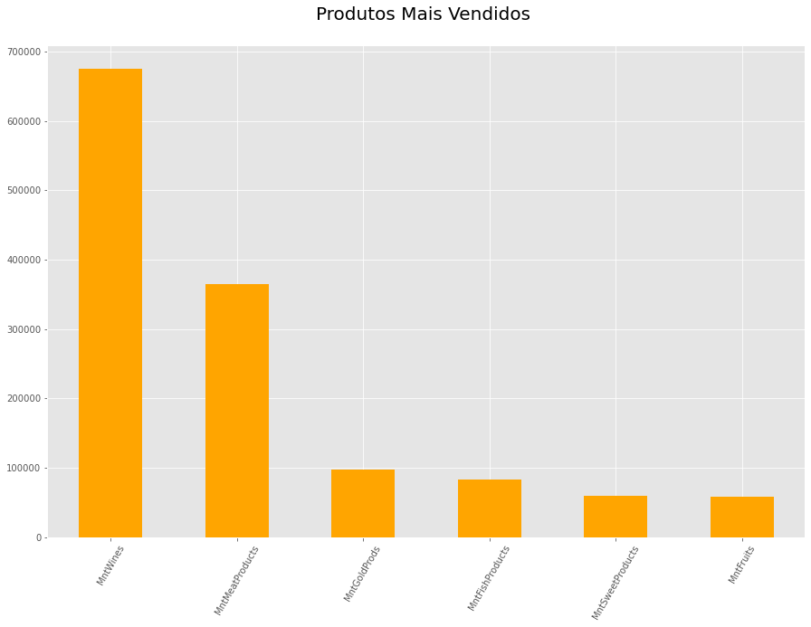

```python
# Pergunta 1.

# Especificando as variáveis.
prod = ['MntWines',
        'MntFruits',
        'MntMeatProducts',
        'MntFishProducts',
        'MntSweetProducts',
        'MntGoldProds']

# Plotagem.
df4[prod].sum().sort_values(ascending = False).plot.bar(color = 'orange')
plt.title('Produtos Mais Vendidos \n', fontdict = {'fontsize':20})
plt.xticks(rotation = 60);
```

- Vinho é o produto mais vendido da empresa.

### P2. Existe correlação significativa entre os produtos?

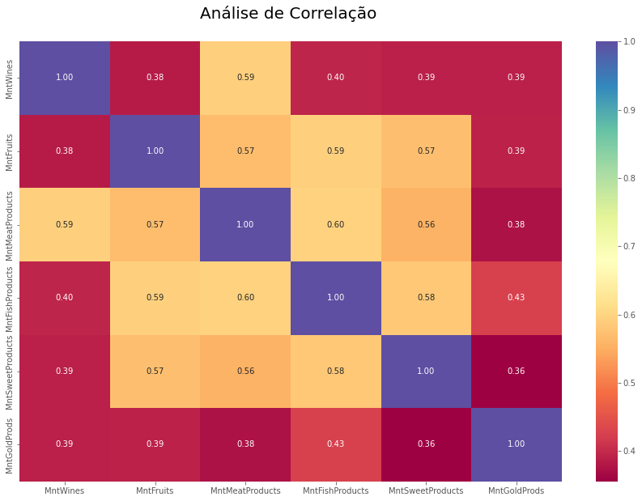

```python
# Pergunta 2.

# Matriz de correlação.
corr_df = df4[['MntWines',
               'MntFruits',
               'MntMeatProducts',
               'MntFishProducts',
               'MntSweetProducts',
               'MntGoldProds']].corr()

# Plotagem.
p1 = sns.heatmap(corr_df,
                 cmap = 'Spectral',
                 annot = True,
                 fmt = '.2f')
p1.set_title('Análise de Correlação \n', size = 20);
```

### P3. Qual campanha de marketing teve maior aceitação entre os clientes?

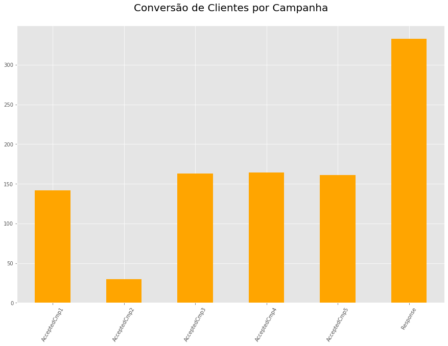

```python
# Pergunta 3.
# Utilizaremos o df3 para responder essa questão.

# Especificando as variáveis.
mkt = ['AcceptedCmp1',
       'AcceptedCmp2',
       'AcceptedCmp3',
       'AcceptedCmp4',
       'AcceptedCmp5',
       'Response']

# Plotagem.
df3[mkt].sum().plot.bar(color = 'orange')
plt.title('Conversão de Clientes por Campanha\n', fontdict = {'fontsize':20})
plt.xticks(rotation = 60);
```

- Considerando a variável **`Response`** sendo a 6º campanha realizada, essa foi a de maior aceitação entre os clientes.

### P4. Qual o local de compras responsável pelo maior número de vendas?

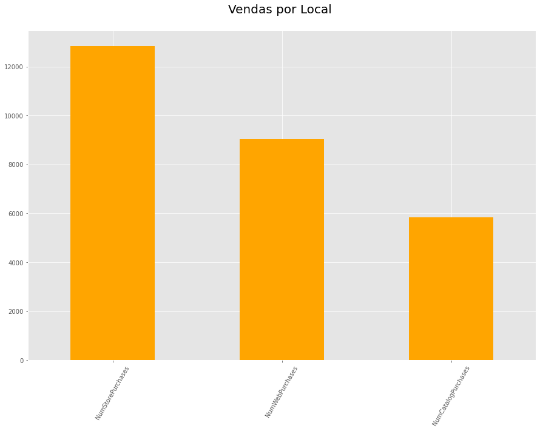

```python
# Pergunta 4.

# Especificando as variáveis.
local = ['NumWebPurchases',
         'NumCatalogPurchases',
         'NumStorePurchases']

# Plotagem.
df4[local].sum().sort_values(ascending = False).plot.bar(color = 'orange')
plt.title('Vendas por Local \n', fontdict = {'fontsize':20})
plt.xticks(rotation = 60);
```

- O maior número de vendas da empresa acontece em lojas físicas.

### H1. Em média, clientes mais jovens compram mais pela internet.

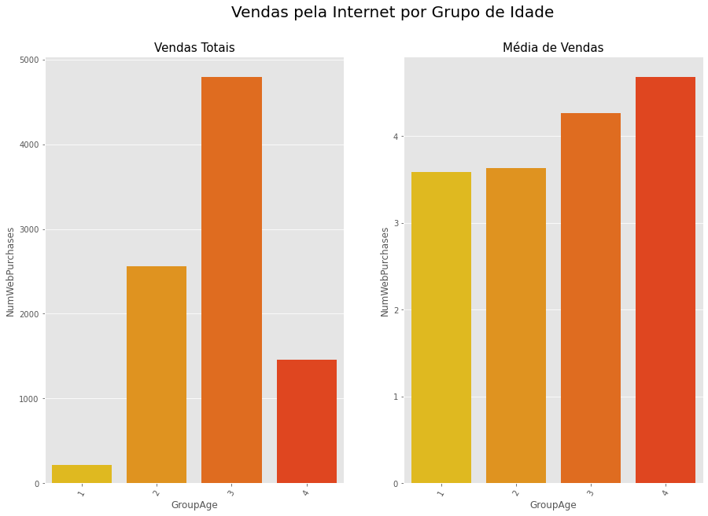

```python
# Hipótese 1.

# Preparando os dados.
h1 = df4[['GroupAge', 'NumWebPurchases']].groupby('GroupAge').sum().reset_index()
h1_1 = df4[['GroupAge', 'NumWebPurchases']].groupby('GroupAge').mean().reset_index()

# Plotagem.
plt.subplot(1, 2, 1)
p1 = sns.barplot(x = 'GroupAge', y = 'NumWebPurchases', data = h1, palette = 'autumn_r')
p1.set_title('Vendas Totais', size = 15)
plt.xticks(rotation = 60)

plt.subplot(1, 2, 2)
p2 = sns.barplot(x = 'GroupAge', y = 'NumWebPurchases', data = h1_1, palette = 'autumn_r')
p2.set_title('Média de Vendas', size = 15)
plt.xticks(rotation = 60)

# Título.
p1.text(x = 2,
        y = 5500,
        s = 'Vendas pela Internet por Grupo de Idade',
        fontsize = 20);
```

- Falsa, podemos observar que os grupos 3 e 4 possuem as maiores médias de compra pela internet.

### H2. Clientes com ensino superior compram mais.

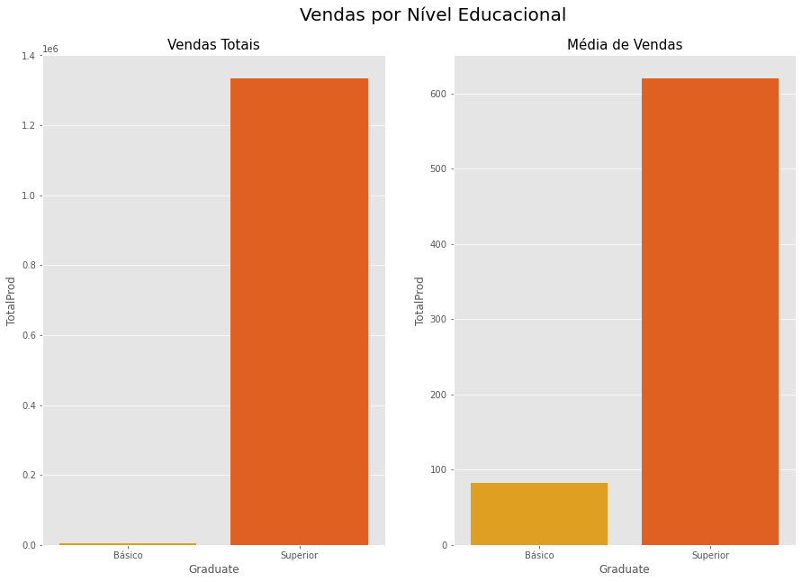

```python
# Hipótese 2

# Preparando os dados.
h2 = df4[['Graduate', 'TotalProd']].groupby('Graduate').sum().reset_index()
h2_1 = df4[['Graduate', 'TotalProd']].groupby('Graduate').mean().reset_index()

# Plotagem.
plt.subplot(1, 2, 1)
p1 = sns.barplot(x = 'Graduate', y = 'TotalProd', data = h2, palette = 'autumn_r')
p1.set_title('Vendas Totais', size = 15);

plt.subplot(1, 2, 2)
p2 = sns.barplot(x = 'Graduate', y = 'TotalProd', data = h2_1, palette = 'autumn_r')
p2.set_title('Média de Vendas', size = 15)

# Título.
p1.text(x = 1,
        y = 1500000,
        s = 'Vendas por Nível Educacional',
        fontsize = 20);
```

- Verdadeira, tanto no número total quanto na média, clientes com ensino superior compram mais.

### H3. Em média, clientes solteiros compram mais que clientes casados.

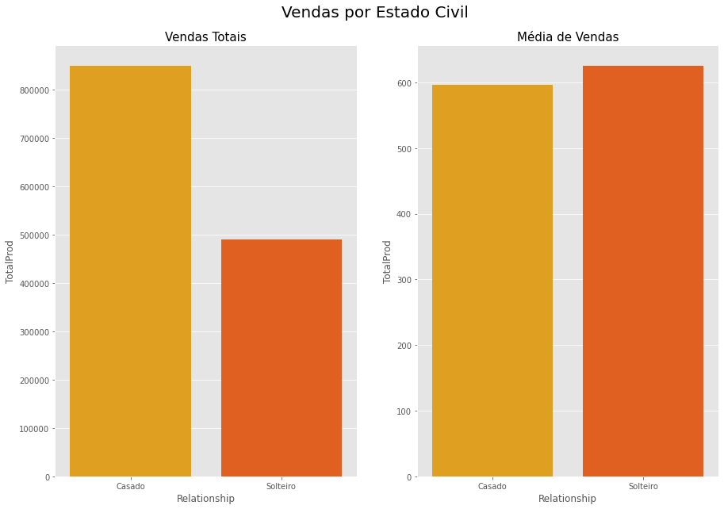

```python
# Hipótese 3

# Preparando os dados.
h3 = df4[['Relationship', 'TotalProd']].groupby('Relationship').sum().reset_index()
h3_1 = df4[['Relationship', 'TotalProd']].groupby('Relationship').mean().reset_index()

# Plotagem.
plt.subplot(1, 2, 1)
p1 = sns.barplot(x = 'Relationship', y = 'TotalProd', data = h3, palette = 'autumn_r')
p1.set_title('Vendas Totais', size = 15);

plt.subplot(1, 2, 2)
p2 = sns.barplot(x = 'Relationship', y = 'TotalProd', data = h3_1, palette = 'autumn_r')
p2.set_title('Média de Vendas', size = 15)

# Título.
p1.text(x = 1.0,
        y = 950000,
        s = 'Vendas por Estado Civil',
        fontsize = 20);
```

- Verdadeira, a média de compras de clientes solteiros é ligeiramente maior.

### H4. Clientes "alta renda" compram mais.

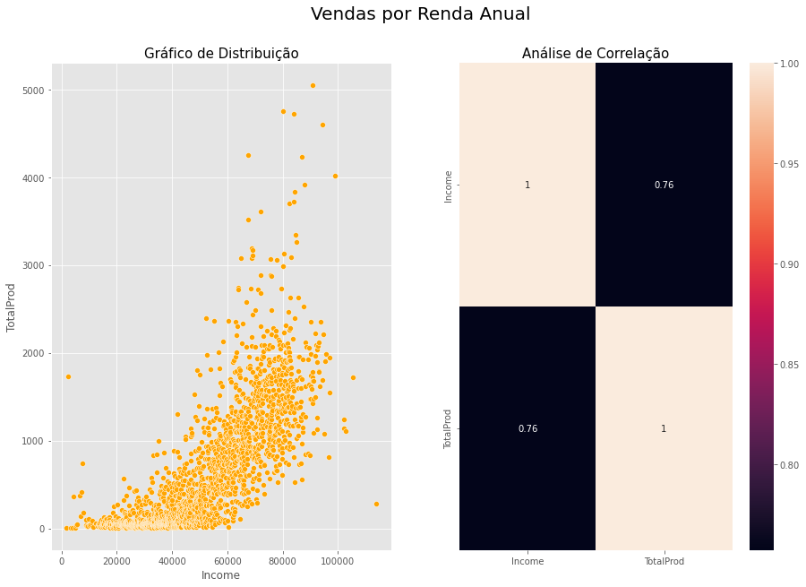

```python
# Hipótese 4.

# Preparação dos dados.
h4 = df4[['Income', 'TotalProd']].groupby('Income').sum().reset_index()

# Plotagem.
plt.subplot(1, 2, 1)
p1 = sns.scatterplot(x = 'Income', y = 'TotalProd', data = h4, color = 'orange')
p1.set_title('Gráfico de Distribuição', size = 15)

plt.subplot(1, 2, 2)
p2 = sns.heatmap(h4.corr(method = 'pearson'), annot = True)
p2.set_title('Análise de Correlação', size = 15)

# Título.
p1.text(x = 90000,
        y = 5800,
        s = 'Vendas por Renda Anual',
        fontsize = 20);
```

- Verdadeira, há uma alta correlação positiva entre a renda do cliente e o total de produtos comprados.

### H5. Clientes que possuem mais filhos compram mais.

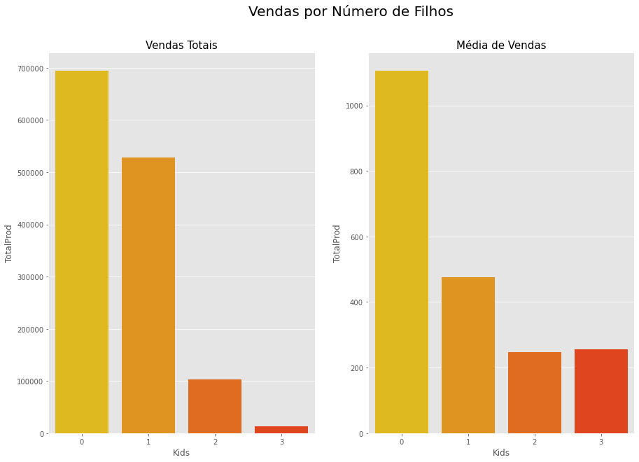

```python
# Hipótese 5

# Preparando os dados.
h5 = df4[['Kids', 'TotalProd']].groupby('Kids').sum().reset_index()
h5_1 = df4[['Kids', 'TotalProd']].groupby('Kids').mean().reset_index()

# Plotagem.
plt.subplot(1, 2, 1)
p1 = sns.barplot(x = 'Kids', y = 'TotalProd', data = h5, palette = 'autumn_r')
p1.set_title('Vendas Totais', size = 15);

plt.subplot(1, 2, 2)
p2 = sns.barplot(x = 'Kids', y = 'TotalProd', data = h5_1, palette = 'autumn_r')
p2.set_title('Média de Vendas', size = 15)

# Título.
p1.text(x = 2.5,
        y = 800000,
        s = 'Vendas por Número de Filhos',
        fontsize = 20);
```

- Falsa, quantos mais filhos os clientes possuem menos eles compram.

### H6. Clientes antigos compram mais que clientes novos.

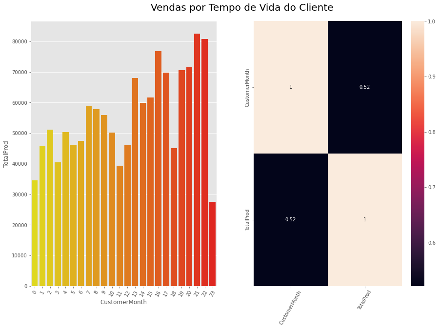

```python
# Hipótese 6.

# Preparando os dados.
h6 = df4[['CustomerMonth', 'TotalProd']].groupby('CustomerMonth').sum().reset_index()

# Plotagem.
plt.subplot(1,2,1)
p1 = sns.barplot(x = 'CustomerMonth', y = 'TotalProd', data = h6, palette = 'autumn_r')
plt.xticks(rotation = 60);

plt.subplot(1,2,2)
p2 = sns.heatmap(h6.corr(method = 'pearson'), annot = True)
plt.xticks(rotation = 60);

# Título.
p1.text(x = 15,
        y = 90000,
        s = 'Vendas por Tempo de Vida do Cliente',
        fontsize = 20);
```

## 5. Análise RFM

A análise RFM é uma estratégia para estimar o valor de um cliente, com base em três variáveis:

- **Recency (recência):** quanto mais recente tiver sido a última compra de um cliente, mais pontos ele recebe aqui.
- **Frequency (frequência):** quanto maior for o número de compras de um cliente, maior também será sua pontuação neste quesito.
- **Monetary (monetário):** quanto maior for o gasto do cliente em compras, maior a pontuação.

### 5.1 Definindo os Preços dos Produtos

Para o cálculo da RFM precisamos saber o preço unitário dos produtos.

Para isso, marcamos uma reunião com a área de negócio onde foi informado os seguintes valores:

- **Vinhos**: são vendidos a 15 reais.
- **Frutas**: são vendidas a 5 reais.
- **Carnes**: são vendidas a 20 reais.
- **Peixes**: são vendidos a 20 reais.
- **Doces**: são vendidos a 10 reais.
- **Produtos Ouro**: são vendidos a 30 reais.

```python
# Definindo os preços dos produtos.
vinho = 15
fruta = 5
carne = 20
peixe = 20
doce = 10
ouro = 30
```

```python
# Variável "Total$".
df4.insert(14, 'Total$',
           (df4['MntWines'] * vinho) +
           (df4['MntFruits'] * fruta) +
           (df4['MntMeatProducts'] * carne) +
           (df4['MntFishProducts'] * peixe) +
           (df4['MntSweetProducts'] * doce) +
           (df4['MntGoldProds'] * ouro))
```

```python
# Visualizando as variáveis
df4[['MntWines',
    'MntFruits',
    'MntMeatProducts',
    'MntFishProducts',
    'MntSweetProducts',
    'MntGoldProds',
    'Total$']].head()
```

|  | MntWines | MntFruits | MntMeatProducts | MntFishProducts | MntSweetProducts | MntGoldProds | Total$ |
| --- | --- | --- | --- | --- | --- | --- | --- |
| 0 | 635 | 88 | 546 | 172 | 88 | 88 | 27845 |
| 1 | 11 | 1 | 6 | 2 | 1 | 6 | 520 |
| 2 | 426 | 49 | 127 | 111 | 21 | 42 | 12865 |
| 3 | 11 | 4 | 20 | 10 | 3 | 5 | 965 |
| 4 | 173 | 43 | 118 | 46 | 27 | 15 | 6810 |

```python
# Dataframe para a análise RFM.
df_seg = df4[['ID',
              'Recency',
              'TotalPurchases',
              'Total$']]
```

```python
# Renomeando as colunas.
df_seg.rename(columns = {'Recency': 'R',
                         'TotalPurchases': 'F',
                         'Total$': 'M'}, inplace = True)
```

```python
# Visualizando o dataframe.
df_seg.head()
```

|  | ID | R | F | M |
| --- | --- | --- | --- | --- |
| 0 | 5524 | 58 | 25 | 27845 |
| 1 | 2174 | 38 | 6 | 520 |
| 2 | 4141 | 26 | 21 | 12865 |
| 3 | 6182 | 26 | 8 | 965 |
| 4 | 5324 | 94 | 19 | 6810 |

**-R (Recência):** indica quantos dias se passaram desde a última compra do cliente.

**-F (Frequência):** indica a quantidade de compras realizadas pelo cliente.

**-M (Monetário):** indica a quantidade monetária gasta pelo cliente.

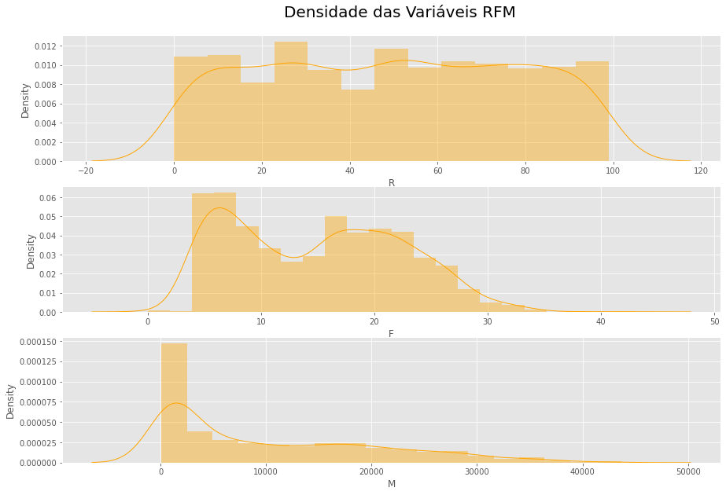

```python
# Densidade das variáveis RFM.

# Plotagem.
plt.subplot(3, 1, 1)
p1 = sns.distplot(df_seg['R'], color = 'orange')

plt.subplot(3, 1, 2)
p2 = sns.distplot(df_seg['F'], color = 'orange')

plt.subplot(3, 1, 3)
p3 = sns.distplot(df_seg['M'], color = 'orange')

# Título.
p1.text(x = 25,
        y = 0.015,
        s = 'Densidade das Variáveis RFM',
        fontsize = 20);
```

### 5.2 Segmentando Clientes

Com os valores RFM definidos podemos iniciar a segmentação. Vamos dividir os dados em quatro quartis.

```python
# Divisão do dataframe.
quantiles = df_seg.quantile(q = [0.25, 0.5, 0.75, 1])
quantiles
```

|  | ID | R | F | M |
| --- | --- | --- | --- | --- |
| 0.25 | 2815.0 | 24.0 | 8.0 | 1290.0 |
| 0.50 | 5455.0 | 49.0 | 15.0 | 6860.0 |
| 0.75 | 8418.0 | 74.0 | 21.0 | 17720.0 |
| 1.00 | 11191.0 | 99.0 | 43.0 | 43675.0 |

Acima temos os valores máximos da RFM para cada quartil.

Porém não faz sentido entregar essa divisão para a empresa, pois o R deve ser baixo, indicando que o cliente está ativo na empresa, e o F e M devem ser altos, pois indicam a frequência e o valor total gasto.

Sendo assim, iremos definir duas funções que irão realizar essa filtragem.

```python
# Convertendo o dataframe.
quantiles = quantiles.to_dict()
```

Com a função *R_Score*, iremos classificar os valores de "R".

Os valores serão classificados em grupos de 1 a 4, onde o grupo 1 receberá os menores valores de R, ou seja, os melhores valores, até o grupo 4, que receberá os valores mais altos de R.

```python
# Função para classificar o "R".
def R_Score(a, b, c):
    if a <= c[b][0.25]:
        return 1
    elif a <= c[b][0.50]:
        return 2
    elif a <= c[b][0.75]:
        return 3
    else:
        return 4
```

Para a função *FM_Score*, a lógica é a mesma da *R_Score*.

Porém aqui, desejamos obter os maiores valores, sendo assim, esses valores serão classificados como 1, e os menores valores como 4.

```python
# Função para classificar o "F" e o "M".
def FM_Score(x, y, z):
    if x <= z[y][0.25]:
        return 4
    elif x <= z[y][0.50]:
        return 3
    elif x <= z[y][0.75]:
        return 2
    else:
        return 1
```

```python
# Classificando valores de "R".
df_seg['R_Score'] = df_seg['R'].apply(R_Score, args = ('R', quantiles))

# Classificando valores de "F".
df_seg['F_Score'] = df_seg['F'].apply(FM_Score, args = ('F', quantiles))

# Classificando valores de "M".
df_seg['M_Score'] = df_seg['M'].apply(FM_Score, args = ('M', quantiles))
```

```python
# Visualizando o dataframe.
df_seg.head()
```

|  | ID | R | F | M | R_Score | F_Score | M_Score |
| --- | --- | --- | --- | --- | --- | --- | --- |
| 0 | 5524 | 58 | 25 | 27845 | 3 | 1 | 1 |
| 1 | 2174 | 38 | 6 | 520 | 2 | 4 | 4 |
| 2 | 4141 | 26 | 21 | 12865 | 2 | 2 | 2 |
| 3 | 6182 | 26 | 8 | 965 | 2 | 4 | 4 |
| 4 | 5324 | 94 | 19 | 6810 | 4 | 2 | 3 |

Com esse dataframe, já podemos filtrar os clientes de acordo com o *Score* desejado.

Para facilitar, vamos criar uma variável concatenando os resultados.

```python
# Variável "RFM_Score".
df_seg['RFM_Score'] = df_seg['R_Score'].astype(str) + df_seg['F_Score'].astype(str) + df_seg['M_Score'].astype(str)
df_seg.head()
```

|  | ID | R | F | M | R_Score | F_Score | M_Score | RFM_Score |
| --- | --- | --- | --- | --- | --- | --- | --- | --- |
| 0 | 5524 | 58 | 25 | 27845 | 3 | 1 | 1 | 311 |
| 1 | 2174 | 38 | 6 | 520 | 2 | 4 | 4 | 244 |
| 2 | 4141 | 26 | 21 | 12865 | 2 | 2 | 2 | 222 |
| 3 | 6182 | 26 | 8 | 965 | 2 | 4 | 4 | 244 |
| 4 | 5324 | 94 | 19 | 6810 | 4 | 2 | 3 | 423 |

```python
# Total de grupos criados.
count = df_seg['RFM_Score'].unique()
print(count)
len(count)
```

```
['311' '244' '222' '423' '112' '233' '144' '344' '421' '333' '111' '133'
 '411' '443' '211' '322' '122' '123' '121' '212' '433' '444' '312' '321'
 '343' '221' '412' '434' '223' '132' '243' '231' '422' '323' '232' '143'
 '131' '334' '134' '332' '234' '432' '431' '331' '142' '113']
```

```
46
```

### 5.3 Rotulando os Grupos de Clientes

Visando diminuir o número de grupos criados na etapa anterior, utilizaremos apenas os *scores* de recência e frequência.

```python
# Variável "RF_Score".
df_seg['RF_Score'] = df_seg['R_Score'].astype(str) + df_seg['F_Score'].astype(str)
```

```python
# Visualizando o dataframe.
df_seg.head()
```

|  | ID | R | F | M | R_Score | F_Score | M_Score | RFM_Score | RF_Score |
| --- | --- | --- | --- | --- | --- | --- | --- | --- | --- |
| 0 | 5524 | 58 | 25 | 27845 | 3 | 1 | 1 | 311 | 31 |
| 1 | 2174 | 38 | 6 | 520 | 2 | 4 | 4 | 244 | 24 |
| 2 | 4141 | 26 | 21 | 12865 | 2 | 2 | 2 | 222 | 22 |
| 3 | 6182 | 26 | 8 | 965 | 2 | 4 | 4 | 244 | 24 |
| 4 | 5324 | 94 | 19 | 6810 | 4 | 2 | 3 | 423 | 42 |

Os grupos serão criados seguindo as regras abaixo:

- **Ativo Especial**: clientes recentes que compram com muita frequência;
- **Ativo Normal**: clientes recentes que compram com menos frequência;
- **Em Atenção**: clientes que compram com muita frequência e que estão a algum tempo sem comprar;
- **Em Alerta**: clientes que compram com menos frequência e que estão a algum tempo sem comprar;
- **Recuperar Importantes**: clientes que compram com muita frequência e que estão a muito tempo sem comprar;
- **Recuperar Médios**: clientes que compram com menos frequência e que estão a muito tempo sem comprar.

```python
# Definindo as regras de negócio.
seg_map = {r'[1-2][1-2]' : 'Ativo Especial',
           r'[1-2][3-4]' : 'Ativo Normal',
           r'[3][1-2]'   : 'Em Atenção',
           r'[3][3-4]'   : 'Em Alerta',
           r'[4][1-2]'   : 'Recuperar Importantes',
           r'[4][3-4]'   : 'Recuperar Médios'}
```

```python
# Rotulando os grupos.
df_seg['Segment'] = df_seg['RF_Score'].replace(seg_map, regex = True)
df_seg.head(10)
```

|  | ID | R | F | M | R_Score | F_Score | M_Score | RFM_Score | RF_Score | Segment |
| --- | --- | --- | --- | --- | --- | --- | --- | --- | --- | --- |
| 0 | 5524 | 58 | 25 | 27845 | 3 | 1 | 1 | 311 | 31 | Em Atenção |
| 1 | 2174 | 38 | 6 | 520 | 2 | 4 | 4 | 244 | 24 | Ativo Normal |
| 2 | 4141 | 26 | 21 | 12865 | 2 | 2 | 2 | 222 | 22 | Ativo Especial |
| 3 | 6182 | 26 | 8 | 965 | 2 | 4 | 4 | 244 | 24 | Ativo Normal |
| 4 | 5324 | 94 | 19 | 6810 | 4 | 2 | 3 | 423 | 42 | Recuperar Importantes |
| 5 | 7446 | 16 | 22 | 10810 | 1 | 1 | 2 | 112 | 11 | Ativo Especial |
| 6 | 965 | 34 | 21 | 9430 | 2 | 2 | 2 | 222 | 22 | Ativo Especial |
| 7 | 6177 | 32 | 10 | 3070 | 2 | 3 | 3 | 233 | 23 | Ativo Normal |
| 8 | 4855 | 19 | 6 | 840 | 1 | 4 | 4 | 144 | 14 | Ativo Normal |
| 9 | 5899 | 68 | 2 | 960 | 3 | 4 | 4 | 344 | 34 | Em Alerta |

```python
# Contagem dos grupos.
df_seg['Segment'].value_counts()
```

```
Ativo Normal             570
Ativo Especial           536
Em Atenção               304
Recuperar Médios         290
Em Alerta                258
Recuperar Importantes    247
Name: Segment, dtype: int64
```

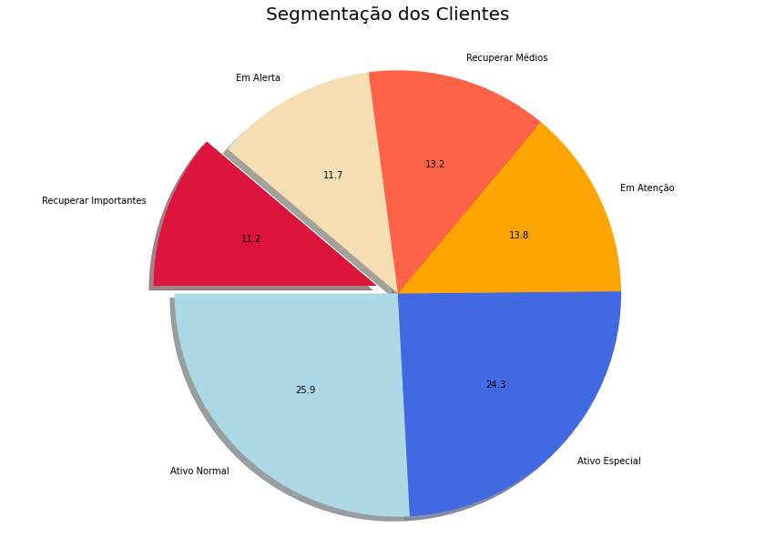

```python
# Segmentação de clientes.
p1 = df_seg['Segment'].value_counts().plot.pie(startangle = 180,
                                               explode = (0, 0, 0, 0, 0, 0.1),
                                               autopct = '%.1f',
                                               shadow = True,
                                               ylabel = '',
                                               colors = ['lightblue',
                                                         'royalblue',
                                                         'orange',
                                                         'tomato',
                                                         'wheat',
                                                         'crimson'])
plt.axis('equal')
plt.title('Segmentação dos Clientes\n', size = 20);
```

## 6. Recomendações para Área de Marketing

Após a análise RFM os clientes foram segmentados em 6 grupos, e agora, podemos criar algumas sugestões de campanhas para cada um deles.

### 6.1 Ativo Especial

Esses são clientes recentes, que compraram com muita frequência.

Para esse grupo, podemos criar campanhas visando recompensar e fidelizar esses clientes, como por exemplo:

- Ter acesso a novos produtos antes do lançamento;
- Oferecer descontos exclusivos.

### 6.2 Ativo Normal

Esse grupo, assim como o anterior, também possui clientes que compraram recentemente, porém, com menor frequência.

Aqui, poderíamos adotar algumas estratégias visando aumentar a frequência de compra dos clientes, como por exemplo:

- Criar promoções estimulando a recompra de outros produtos;
- Criar programas de fidelidade.

### 6.3 Em Atenção

Esse grupo merece atenção pois possui clientes que compraram com muita frequência e que estão "hibernados" a algum tempo.

Isso pode ser um sinal de que a BestShop está perdendo bons clientes para a concorrência e devemos evitar que isso ocorra.

Poderíamos criar algumas estratégias como:

- Oferecer descontos baseados em produtos comprados anteriormente;
- Criar promoções "cobrindo" as ofertas da concorrência.

### 6.4 Em Alerta

Esse pode ser considerado um grupo de clientes que compram eventualmente.

Aqui, poderíamos adotar algumas estratégias semelhantes ao grupo anterior visando reativar o interesse desses clientes.

### 6.5 Recuperar Importantes

Nesse grupo, temos clientes que já compraram com muita frequência e que atualmente estão inativos.

Devemos adotar estratégias visando recuperar esses clientes, como por exemplo:

- Apresentar e oferecer novos produtos baseado no histórico de compras;
- Investir em pesquisas de feedback para descobrir as principais causas do *churn*.

### 6.6 Recuperar Médios

Esse grupo se trata de clientes que compraram com menos frequência e que estão a muito tempo sem comprar.

Semelhante ao ocorrido com o grupo anterior, devemos focar em reviver o interesse do cliente.

- Oferecer produtos e descontos especiais;
- Criar campanhas de alcance customizadas.

## 7. Conclusões Finais

Neste projeto, utilizamos a linguagem Python e algumas de suas principais bibliotecas para segmentar a base de clientes da BestShop.

A segmentação foi realizada através da análise RFM, que é uma ótima maneira de identificar quais são os clientes mais e menos engajados da empresa. Além disso, também realizamos uma breve análise exploratória nos dados, respondendo perguntas e hipóteses de negócio, com o objetivo de entender e extrair insights dos dados.

O resultado da segmentação dos clientes gerou seis grupos, onde cada um deles possui um padrão de consumo específico, o que possibilita a empresa direcionar ações customizadas para cada grupo, visando aumentar as taxas de conversão das campanhas de Marketing.